# Prosper Loan Data Exploration

## by Mohanad Salem

## Investigation Overview

I chose the univariate plots to be the Loan status, employment status and the stated monthly income. The bivariate to be the Loan Status vs Loan Amount and Loan Status vs Prosper Rating. Finally, in the multivariate phase I plotted (Listing Categories vs Loan Amount vs Loan Status) and (Listing Categories vs Prosper Rating vs Loan Status)

## Dataset Overview

Loan Data from Prosper: This data set contains 113,937 loans with 81 variables on each loan, including loan amount, employment status, current loan status, borrower income, and many others.

## Loan Status

1st Observation:

- I can see here that most of the loans are current.
- Also a high amount of the loans are completed.
- The charged off loans are low but not as low as the defaulted loans.
- lastly we have the past due loans which are split into groups based on a range of days

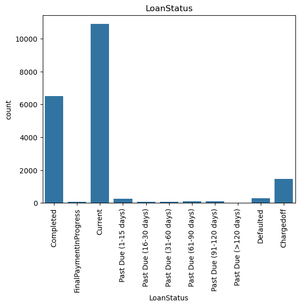

## Employment Status

2nd Observation:

- As expected, people who are Employed are the majority and Not-Employed are the least.
- From the rest of the minorities, the Full-time is the highest.

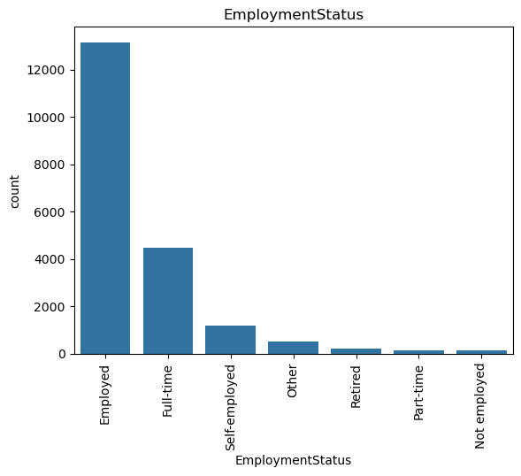

## Stated Monthly Income

3rd Observation:

- The Monthly Income is right skewed and the its peak is at 4000

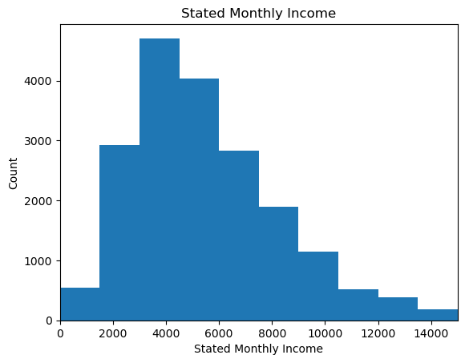

## Loan Status and Prosper Rating

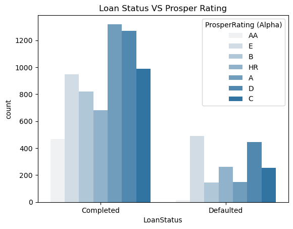

## Loan Status and Loan Amount

2nd observation:

- It looks like the defaulted loans are larger than the completed loans

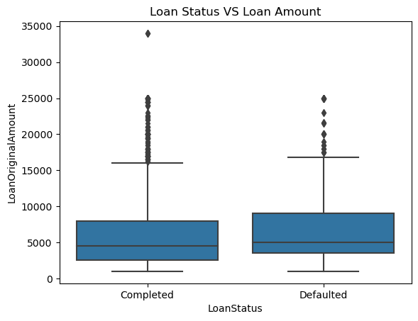

### Emplyment Status, Loan Amount and Loan Status

1st observation:

- Defaulted loans are larger than completed loans
- big loans tends to be for employed then self employed.
- also some big loans were assigned to 'other' and its percentage of defaulted loans is high.

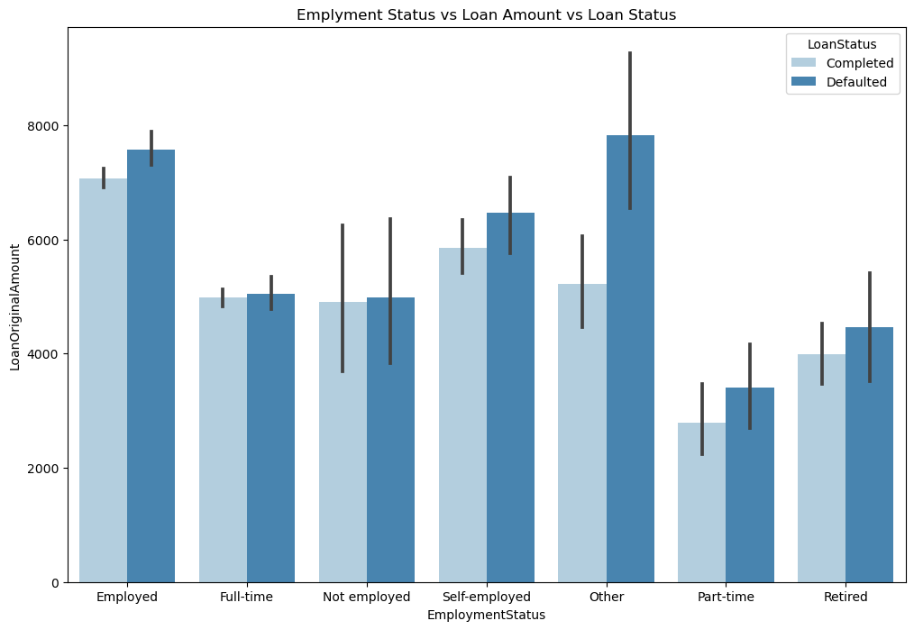

## Listing Categories, Loan Amount and Loan Status

2nd observation:

- Defaulted loans tends to be higher than completed loans in all categories
- Business category seems to have the highest amount

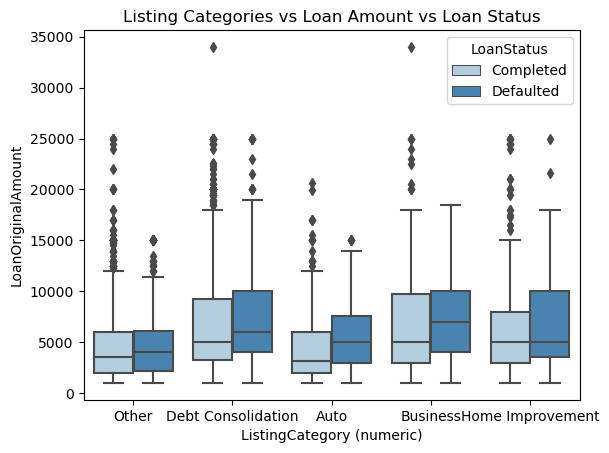

## Listing Categories, Prosper Rating and Loan Status

3rd observation:

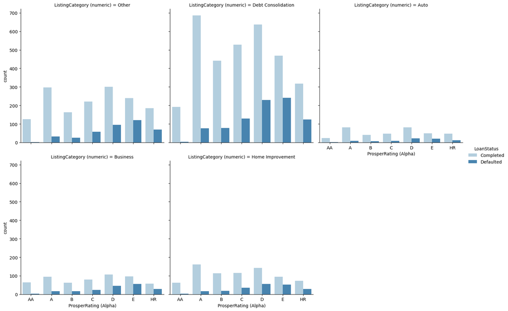